# Spatio-temporal Modelling, Lab 1 2024-10-16

## 1 Allgemeine Informationen

**Kontakt:**

Christian Knoth

- Mail: christianknoth@uni-muenster.de
- Raum: 137

LearnWeb:

Übungen:

- müssen nicht eingereicht werden
- werden nicht korrigiert

ABER:

- sind wichtig um die Inhalte der Vorlesung besser zu verstehen
- zeigen wie man die Modelle, die in der Vorlesung behandelt werden, in der Praxis anwenden kann
- sind wichtig, um die Klausur zu bestehen

Heute werden wir uns mit einigen Grundlagen von [R Studio](http://www.rstudio.com/ide/) beschäftigen.

Im Anschluss werdet ihr an den ersten Übungen arbeiten, die sich um random walk und AR-Prozesse drehen.

Wenn Ihr Eure R-Kenntnisse auffrischen oder etwas nachschlagen wollt, könnte dies hier nützlich für Euch sein: [R introduction](http://cran.r-project.org/doc/manuals/r-release/R-intro.html)

## 2 RStudio

Schritte:

1. Ladet RStudio [hier](http://www.rstudio.com/ide/download/) herunter und installiert es.
2. Die Grundlagen von RStudio sind hier beschrieben: [documentation page](http://www.rstudio.com/ide/docs/). Bitte lest sie und pobiert zumindest den Abschnitt **Using RStudio**. Findet heraus wie man das Hilfe-Fenster verwendet.
3. Zudem findet ihr im Learnweb zwei Videos mit einer Einführung in bzw. Übersicht über R und Rstudio.

## 3 Generierung von Random Walk Daten

Für die erste Übung müssst Ihr Zufallszahlen generieren. Dieses Beispiel erstellt 10 Zufallszahlen aus der Standarnormalverteilung mit Hilfe der **rnorm** Funktion:

```r
xr = rnorm(10)
xr
```

```
 [1] -0.20573820 -0.45841370 -1.40934400 -0.12735989  0.92312797 -1.23325016
 [7]  0.13147188  0.05588523 -0.46987410  1.65046707
```

Das Ergebnis wird im unteren Fenster angezeigt. **norm** steht für die Normalverteilung und das **r**-Präfix für das Generieren von Zufallszahlen. Seht Euch die Hilfe zu **rnorm** im Hilfe-Fenster in RStudio an. Ihr könnt auch andere Präfixe für **norm** verwenden: **dnorm** liefert die Dichte für Quantile (Dichtefunktion), **pnorm** den Wert der Verteilungsfunktion für Quantile und **qnorm** die Quantile für Wahrscheinlichkeiten.

Das folgende Beispiel plottet die Dichtefunktion der Standardnormalverteilung. Um die die Dichtewerte zu bekommen, verwenden wir die **seq**-Funktion, die die Quantile generiert. Wir übergeben dann die Werte (**x**) an die Dichtefunktion (**dnorm**) und schließlich die beiden Vektoren (**x**,**xd**) an die **plot**-Funktion. **type=l** bedeutet, dass eine Linie im Plot gezeichnet werden soll (lasst diesen Parameter weg und seht, was passiert)

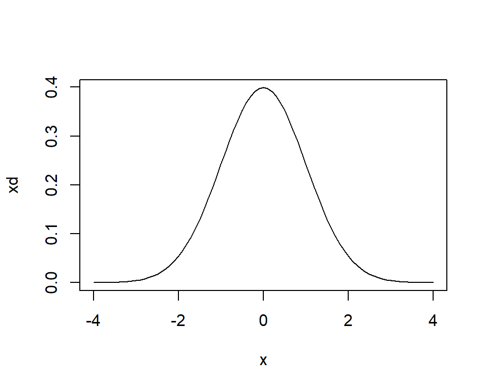

```r
x = seq(from=-4, to=4, by=0.1)
xd = dnorm(x)
plot(x,xd,type="l")
```

Wir können das gleiche auch mit der Verteilungsfunktion machen:

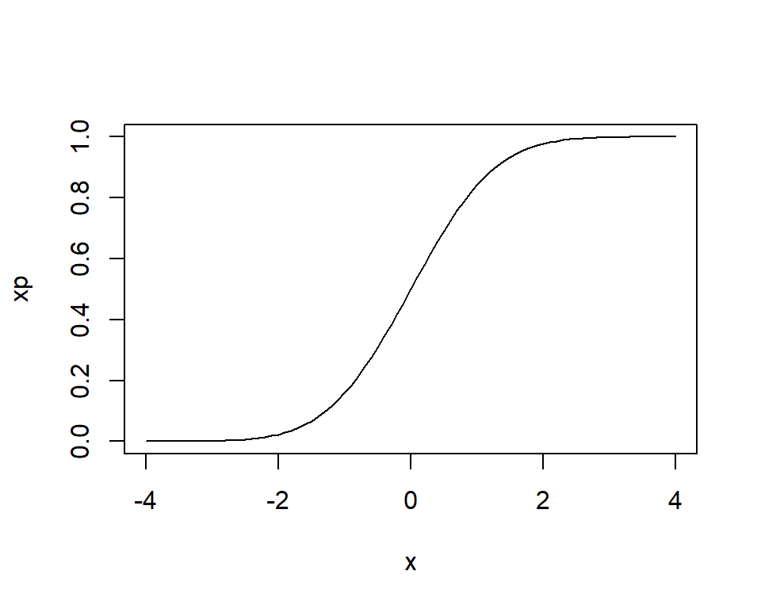

```r
xp = pnorm(x)
plot(x,xp,type="l")
```

Zurück zu unserer Übung: Wir können die **cumsum**-Funktion benutzen um die kumulative Summe zu berechnen. Diese kann dann benutzt werden um den Random Walk-Prozess zu generieren wie in Übung 1. Wir können die Ergebnisse auch plotten.

```r
xr
```

```
 [1] -0.20573820 -0.45841370 -1.40934400 -0.12735989  0.92312797 -1.23325016
 [7]  0.13147188  0.05588523 -0.46987410  1.65046707
```

```r
xcs = cumsum(xr)
xcs
```

```
 [1] -0.2057382 -0.6641519 -2.0734959 -2.2008558 -1.2777278 -2.5109780
 [7] -2.3795061 -2.3236209 -2.7934950 -1.1430279
```

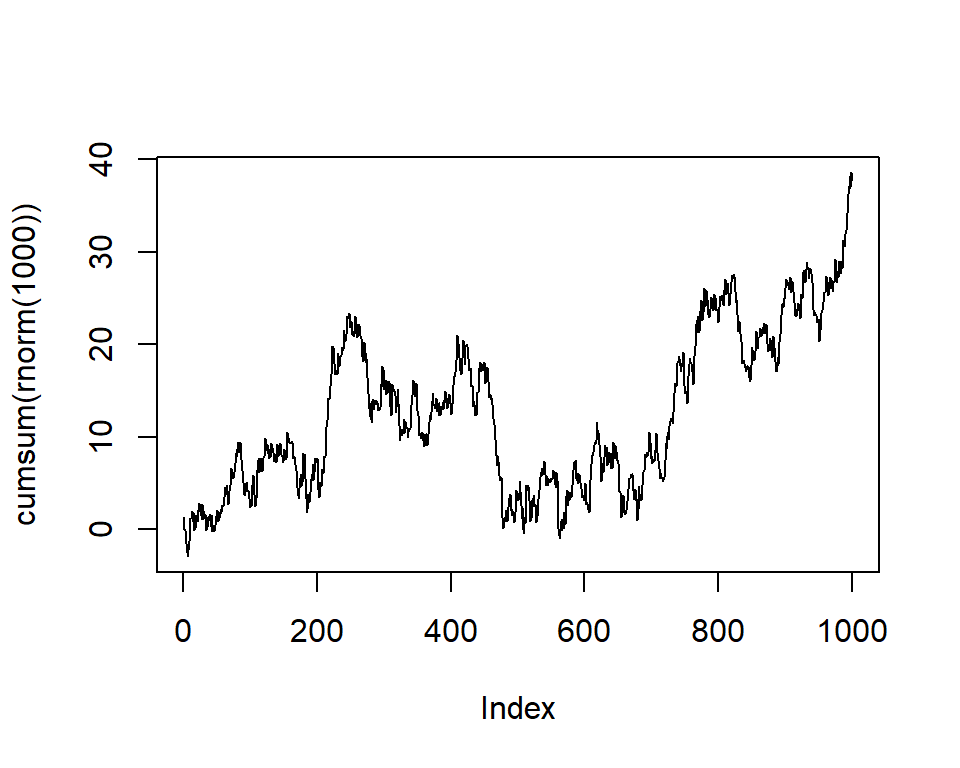

```r
plot(cumsum(rnorm(1000)),type='l')
```

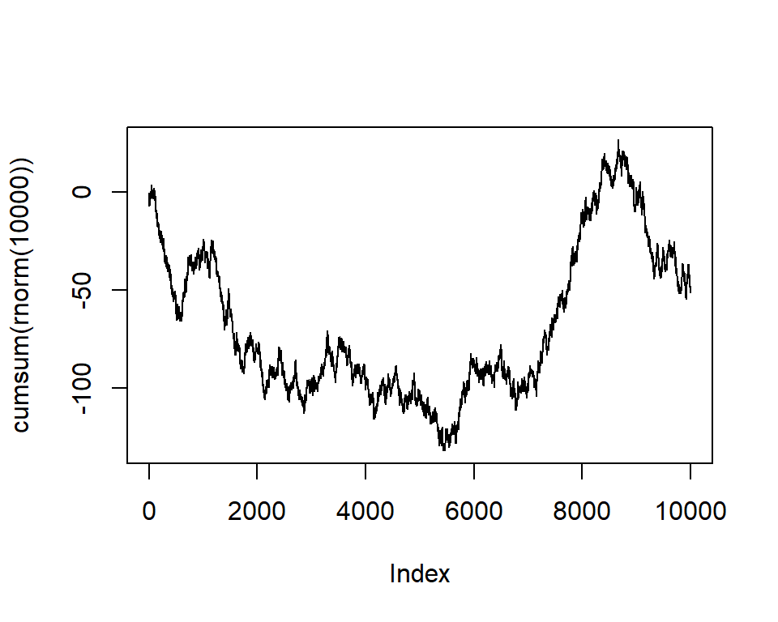

```r
plot(cumsum(rnorm(10000)),type='l')
```

#### *Übung 1*

**Übung 1**

*Steigt der Random Walk Prozess generell an, fällt er ab oder hat er keine dominante Richtung?*

#### *Übung 2*

**Übung 2**

```r
var(cumsum(rnorm(10)))
```

```
[1] 2.750577
```

```r
var(cumsum(rnorm(100)))
```

```
[1] 16.85141
```

```r
var(cumsum(rnorm(1000)))
```

```
[1] 676.046
```

```r
var(cumsum(rnorm(10000)))
```

```
[1] 5327.646
```

```r
var(cumsum(rnorm(100000)))
```

```
[1] 5068.5
```

```r
var(cumsum(rnorm(1000000)))
```

```
[1] 558328.2
```

*Erklärt warum ein Random Walk eine Varianz hat, die mit der Zeit zunimmt!*

## 4 Generierung von AR-Prozessen

Seht Euch die folgende Funktion zur Generierung eines AR-Prozesses an.

```r
generate.ar <- function(n, beta, sd=1)
{
  ar = rnorm(length(beta),0,sd)
  for (t in (length(beta)+1):n) {
    y <- sum(ar[(t-1):(t-length(beta))] * beta) + rnorm(1,0,sd)
    ar = c(ar,y)
  }
  return(ar)
}
```

Die Parameter können wie folgt beschrieben werden:

- `n` beschreibt die Länge der Zeitreihe, die erstellt werden soll
- `beta` ist ein Vektor mit AR-Koeffizienten, wobei `length(beta)` die Ordnung des AR-Prozesses bestimmt
- `sd` repräsentiert die Standardabweichung der normalverteilten Innovationen $\epsilon_i$.

Der folgende Aufruf generiert und plottet einen AR(2)-Prozess mit den Koeffizienten $(0.5,0.2)$

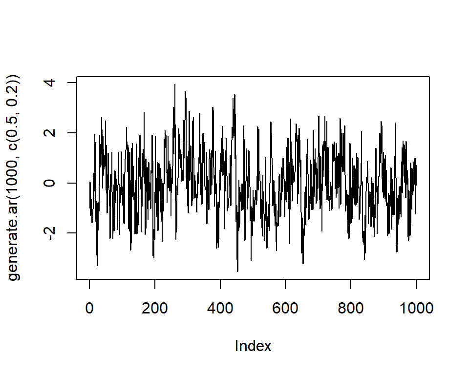

```r
plot(generate.ar(1000, c(0.5,0.2)), type="l")
```

#### *Übung 3*

**Übung 3**

*Welche Werte für `beta` kann man nutzen, um (i) weißes Rauschen (white noise) und (ii) ‘random walk’- Prozesse zu erstellen?*

#### *Übung 4*

**Übung 4**

*Betrachtet den AR(2) Prozess oben: Steigt seine Varianz mit der Länge an?*

#### *Übung 5*

**Übung 5**

Die R-Funktionen `acf()` und `pacf()` erstellen einen Plot der empirischen (partiellen) Autokorrelation einer gegebenen Zeitreihe (siehe `?acf` und `?pacf` für mehr Details).

*Generiert einige AR-Prozesse unterschiedlicher Ordnung und probiert verschiedenene Werte für `beta`. Plottet sowohl Autokorrelation als auch partielle Autokorrelation und beschreibt wie diese sich mit unterschiedlicher Länge und unterschiedlichen Parameterwerten verändern.*

**Beachte:** Die Koeffizienten müssen vorsichtig gewählt werden um valide Prozesse zu generieren. Als Faustregel kann die Formel genutzt werden $\sum |\beta_i| < 1$.